# Amphibians - LTEM - Yellow Point Bog Ecological Reserve

Published

2023-03-31

# 1 Issues with this protocol that need to be resolved before doing any analyses

- Multiple types of transects. Both auditory and visual transects can be performed, and sometimes in the same year. Different species can be detected under each type of survey (e.g., salamanders cannot be detected under auditory surveys).
- Timing of survey. In some site.years, multiple surveys are conducted. How should these be combined? For example, amphibians may be more vocal during the breeding season and not outside the breeding season. The breeding season may be site.year.species dependent.
- Accounting for detection probabilities. Just because an amphibian species was not detected, does not imply that was not present. The surveyor may have been unlucky and not seen/heard the species when the transect was run.

I recommend that a revised protocol based on the North American Amphibian Monitoring Plan be used that accounts for the above factors. The survey protocol has been extensively field tested and should give you much better data. As well, Parks Canada has an amphibian monitoring plan for sites in the Banff/Lake Louise/Yoho Parks area that could also be adopted quickly.

I don’t thing that this protocol will yield anything useful in its present form.

# 2 Summary of Amphibian LTEM protocol

## 2.1 Basic protocol

There are two protocols – calls and visual surveys.

As taken from the protocol document for call surveys:

> “Define a survey transect along or through your wetland. … Surveyors visit the monitoring site(s) in spring and listen for calling males, recording the SPECIES_CODE and approximate number of each. Repeat surveys increase the probability that SPECIES_CODE will be detected.”

As taken form the protocol document for visual surveys:

> “Surveyors monitor breeding site(s) during the active season (spring to fall), walking the shoreline of a wetland recording all SPECIES_CODE and life stages encountered. These include egg masses, tadpoles and adults. Repeat surveys increase the probability that SPECIES_CODE will be detected.”

The data collected under this protocol at each survey consists of:

- SPECIES_CODE. The SPECIES_CODE of amphibian counted.
- Life Stage. The life stage of the SPECIES_CODE.
- Count. The number of amphibians at this lifestage.

## 2.2 Cautions about the protocol.

### 2.2.1 Don’t use 0 to indicate a missing value.

If no SPECIES_CODE were seen during a visit, this is indicated by the lack of a record for that visit. It will be necessary to assume that all SPECIES_CODE will have been searched for at each visit and that lack of count for a SPECIES_CODE implies it was searched for and not seen, rather than the observed did not know how to identify the SPECIES_CODE.

It is unclear how NO amphibians of SPECIES_CODE will be recorded in the database?

If no visit was made to a transect, then there are no records in the General Survey for that transect. One must infer that if there are no records for transect at a date that it was not visited. The Transect Information worksheet only has information on the transect label and not when they were visited. It is preferable to include in this sheet the visit dates of each transect in that year explicitly rather than trying to infer this information from the General Survey sheet.

**This may have been corrected in the new datasets**

## 2.3 Database structure

The database for this protocol is a series of Excel workbooks with multiple sheets in each workbook. The Transect Information sheet contains the information on the transect available for this year. If a transect is not visited, this is indicated by a no records in the General Survey workseeht. The General Survey sheet contains the information collected. There are multiple lines per visit. If a visit was done but no amphibians were detected, then the SPECIES_CODE code is set to missing with a count of 0.

The relevant fields on the General Survey worksheet are:

- *Transect* Label.
- *Date*. The date the data was collected. The Year is extracted from this date.
- SPECIES_CODE. What SPECIES_CODE were seen
- *EggMasses* - number of eggmasses detected
- *Adults* - number of adults counted

# 3 Reading and checking the data

The database was read for all record pertaining to the Yellow Point Bog Ecological Reserve. The following files were found:

The following surveys were found:

```
Surveys with the data
```

```
   SPI_PROJECT_ID SURVEY_ID          START_DATE
53           5572     40436 2013-04-30 17:00:00
54           5572     40437 2014-03-31 17:00:00
55           5572     40438 2015-02-28 16:00:00
56           5572     40439 2020-03-31 17:00:00
57           5572     40440 2017-03-31 17:00:00
58           5572     40441 2019-03-31 17:00:00
59           5572     40442 2020-03-31 17:00:00
61           5572     40476 2018-03-31 17:00:00
75           5572     47183 2021-05-03 17:00:00
                       STUDY_AREA_NAME
53 Yellow Point Bog Ecological Reserve
54 Yellow Point Bog Ecological Reserve
55 Yellow Point Bog Ecological Reserve
56 Yellow Point Bog Ecological Reserve
57 Yellow Point Bog Ecological Reserve
58 Yellow Point Bog Ecological Reserve
59 Yellow Point Bog Ecological Reserve
61 Yellow Point Bog Ecological Reserve
75 Yellow Point Bog Ecological Reserve
```

The following data editing was performed

## 3.1 Variables names corrected for *R*

Variable names in *R* must start with a letter and contain letters or numbers or underscores. Blanks in variable names are not normally allowed, nor are special characters such as %. These are normally replaced by periods (“.”) in the variable name.

```
Original variable names in data frame
```

```
  [1] "DESIGN_COMPONENT_ID"            "TAXONOMIC_UNIT_ID"
  [3] "SURVEY_ID"                      "SPI_PROJECT_ID"
  [5] "STUDY_AREA_ID"                  "STUDY_AREA_VISIT_ID"
  [7] "DESIGN_COMPONENT_VISIT_ID"      "VISIT_START_DATE"
  [9] "VISIT_START_TIME"               "OBSERVATION_DATETIME"
 [11] "OBSERVATION_YEAR"               "OBSERVATION_MONTH"
 [13] "OBSERVATION_DAY"                "VISIT_END_DATE"
 [15] "VISIT_END_TIME"                 "VISIT_TIME_SPAN"
 [17] "VISIT_TIME_SPAN_UNIT_CODE"      "VISIT_TIME_SPAN_UNIT_NAME"
 [19] "VISIT_TIME_SPAN_UNIT_DEFN_URL"  "TRAP_EVENT_CODE"
 [21] "TRAP_EVENT_NAME"                "TRAP_EVENT_DEFN_URL"
 [23] "TRAPS_SPRUNG"                   "DISTANCE_COVERED_KM"
 [25] "NIGHTS_TRAPPED"                 "SAMPLES"
 [27] "VISIT_NOTE"                     "NO_OBSERVATIONS_IND"
 [29] "TRIGGER_QUIET_PERIOD_SEC"       "TRIGGER_SENSITIVITY"
```

[output cut: 44 more lines]

```
Corrected variable names of data frame
```

```
  [1] "DESIGN_COMPONENT_ID"            "TAXONOMIC_UNIT_ID"
  [3] "SURVEY_ID"                      "SPI_PROJECT_ID"
  [5] "STUDY_AREA_ID"                  "STUDY_AREA_VISIT_ID"
  [7] "DESIGN_COMPONENT_VISIT_ID"      "VISIT_START_DATE"
  [9] "VISIT_START_TIME"               "OBSERVATION_DATETIME"
 [11] "OBSERVATION_YEAR"               "OBSERVATION_MONTH"
 [13] "OBSERVATION_DAY"                "VISIT_END_DATE"
 [15] "VISIT_END_TIME"                 "VISIT_TIME_SPAN"
 [17] "VISIT_TIME_SPAN_UNIT_CODE"      "VISIT_TIME_SPAN_UNIT_NAME"
 [19] "VISIT_TIME_SPAN_UNIT_DEFN_URL"  "TRAP_EVENT_CODE"
 [21] "TRAP_EVENT_NAME"                "TRAP_EVENT_DEFN_URL"
 [23] "TRAPS_SPRUNG"                   "DISTANCE_COVERED_KM"
 [25] "NIGHTS_TRAPPED"                 "SAMPLES"
 [27] "VISIT_NOTE"                     "NO_OBSERVATIONS_IND"
 [29] "TRIGGER_QUIET_PERIOD_SEC"       "TRIGGER_SENSITIVITY"
```

[output cut: 44 more lines]

## 3.2 How many years of data are available?

```
The number of TRANSECTS run by year are
```

```
                                     Year
STUDY_AREA_NAME                       2013 2014 2015 2016 2017 2018 2019 2020
  Yellow Point Bog Ecological Reserve    5    8    4    5    4    4    2    3
                                     Year
STUDY_AREA_NAME                       2021
  Yellow Point Bog Ecological Reserve   56
```

## 3.3 Checking Study Area Name

The Study Area Name should be recorded consistently across years, otherwise it may indicate that different sites are being studies. The study area name is converted to Title Case.

The list of Study Area Names by year in the data is:

```
                                     Year
STUDY_AREA_NAME                       2013 2014 2015 2016 2017 2018 2019 2020
  Yellow Point Bog Ecological Reserve    5    8    4    5    4    4    2    3
                                     Year
STUDY_AREA_NAME                       2021
  Yellow Point Bog Ecological Reserve   56
```

You should also check the transect labels for typos, e.g., inconsistencies across years. This is difficult to automate and needs a human touch.

```
                                     TRANSECT
STUDY_AREA_NAME                       Listening station (auditory survey)
  Yellow Point Bog Ecological Reserve                                  18
                                     TRANSECT
STUDY_AREA_NAME                       Station 1 (visual) Station 2 (visual)
  Yellow Point Bog Ecological Reserve                 13                 60
```

```
                                     Year
TRANSECT                              2013 2014 2015 2016 2017 2018 2019 2020
  Listening station (auditory survey)    1    1    0    0    0    0    0    0
  Station 1 (visual)                     2    2    1    1    2    1    1    1
  Station 2 (visual)                     2    5    3    4    2    3    1    2
                                     Year
TRANSECT                              2021
  Listening station (auditory survey)   16
  Station 1 (visual)                     2
  Station 2 (visual)                    38
```

## 3.4 Checking SPECIES_CODE code

The SPECIES_CODE code should be the same across the files.

```
            Year
SPECIES_CODE 2013 2014 2015 2016 2017 2018 2019 2020 2021
    A-AMGR      0    2    2    0    2    1    0    2    4
    A-LICA      2    2    2    0    0    1    0    0   14
    A-PSRE      1    3    0    3    0    2    2    1   29
    A-RAAU      0    0    0    1    0    0    0    0    0
    AMPHIBIA    2    0    0    1    0    0    0    0    0
    NULL        0    1    0    0    2    0    0    0    9
```

```
*** WARNING *** More than one SPECIES_CODE name found


The number of records by SPECIES_CODE and year are
```

```
            Year
SPECIES_CODE 2013 2014 2015 2016 2017 2018 2019 2020 2021
    A-AMGR      0    2    2    0    2    1    0    2    4
    A-LICA      2    2    2    0    0    1    0    0   14
    A-PSRE      1    3    0    3    0    2    2    1   29
    A-RAAU      0    0    0    1    0    0    0    0    0
    AMPHIBIA    2    0    0    1    0    0    0    0    0
    NULL        0    1    0    0    2    0    0    0    9
```

# 4 Single Site Analysis

Date for the Yellow Point Bog Ecological Reserve are available from 2013 to 2021.

All analyses were done using the R (R Core Team, 2022) analysis system. The *R* code is general enough that if more than one transect is present, it will automatically choose the more complex linear mixed models as seen in the other protocols. All plots are also saved as separate *png files for inclusion into other reports.

## 4.1 Number of Egg Masses

This analysis will look at trend in the total number of detected egg masses (for each SPECIES_CODE, and over all SPECIES_CODE). The current data is extremely sparse at the SPECIES_CODE level and likely to be uninformative.

We also need to make the strong assumption that egg masses are not double counted across multiple visits to the same transect. There is no information stored on the database on the exact location where an egg mass was located so it is difficult to verify this information.

Even if the above assumptions are satisfied, the number of observed egg masses is only an **INDEX** to the population number of egg masses.

The data is first summarized to the year level for each transect counting the number of records that identify an egg mass. This reduces the data to one measurement per transect per site/year.

We first need to impute 0 values for a SPECIES_CODE if not listed as being detected in a year.

```r
# Must impute 0 values for SPECIES_CODE not present in a year


xtabs(~Year+EggMasses,  data=amph.df, exclude=NULL, na.action=na.pass)
```

```
      EggMasses
Year    1  3 <NA>
  2013  0  0    5
  2014  0  0    8
  2015  0  0    4
  2016  0  0    5
  2017  0  0    4
  2018  0  0    4
  2019  0  0    2
  2020  2  1    0
  2021  0  0   56
```

```r
xtabs(EggMasses ~ SPECIES_CODE+Year, data=amph.df, exclude=NULL, na.action=na.pass)
```

```
            Year
SPECIES_CODE 2013 2014 2015 2016 2017 2018 2019 2020 2021
    A-AMGR      0              0              0    4
    A-LICA                     0    0         0    0
    A-PSRE                0         0              1
    A-RAAU      0    0    0         0    0    0    0    0
    AMPHIBIA         0    0         0    0    0    0    0
    NULL        0         0    0         0    0    0
```

**DATA is NOT consistent across years**

```
The number of egg masses counted by SPECIES_CODE
```

```
                       STUDY_AREA_NAME                            TRANSECT Year
1  Yellow Point Bog Ecological Reserve Listening station (auditory survey) 2013
2  Yellow Point Bog Ecological Reserve Listening station (auditory survey) 2014
3  Yellow Point Bog Ecological Reserve Listening station (auditory survey) 2021
4  Yellow Point Bog Ecological Reserve Listening station (auditory survey) 2021
5  Yellow Point Bog Ecological Reserve                  Station 1 (visual) 2013
6  Yellow Point Bog Ecological Reserve                  Station 1 (visual) 2013
7  Yellow Point Bog Ecological Reserve                  Station 1 (visual) 2014
8  Yellow Point Bog Ecological Reserve                  Station 1 (visual) 2014
9  Yellow Point Bog Ecological Reserve                  Station 1 (visual) 2015
10 Yellow Point Bog Ecological Reserve                  Station 1 (visual) 2016
11 Yellow Point Bog Ecological Reserve                  Station 1 (visual) 2017
12 Yellow Point Bog Ecological Reserve                  Station 1 (visual) 2017
13 Yellow Point Bog Ecological Reserve                  Station 1 (visual) 2018
14 Yellow Point Bog Ecological Reserve                  Station 1 (visual) 2019
```

[output cut: 65 more lines]

```
[1] STUDY_AREA_NAME TRANSECT        Year            SPECIES_CODE
[5] EggMasses
<0 rows> (or 0-length row.names)
```

```
A summary of the egg-masses seen by SPECIES_CODE and year is
```

```
                  Year
SPECIES_CODE       2013 2014 2015 2016 2017 2018 2019 2020 2021
  A-PSRE              0    0    0    0    0    0    0    1    0
  NULL                0    0    0    0    0    0    0    0    0
  A-LICA              0    0    0    0    0    0    0    0    0
  AMPHIBIA            0    0    0    0    0    0    0    0    0
  A-AMGR              0    0    0    0    0    0    0    4    0
  A-RAAU              0    0    0    0    0    0    0    0    0
  ALL.SPECIES_CODE    0    0    0    0    0    0    0    5    0
```

A summary plot of the (reduced) data is shown in Figure 1.

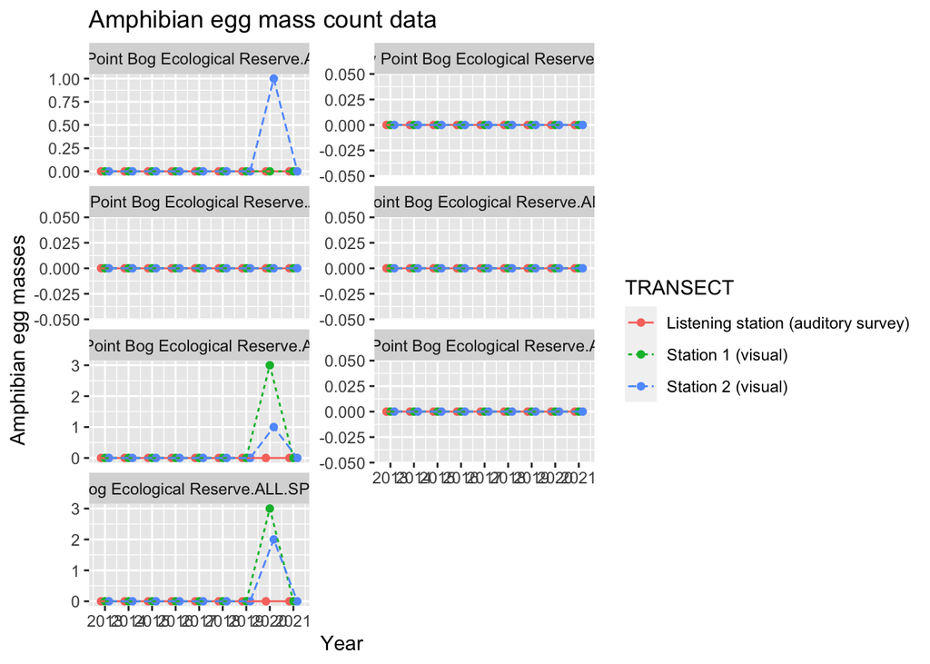

Figure 1: Summary plot of the number of egg masses seen during VI count.

If a single transect is done in each year, a (quasi)-Poisson generalized linear model is fit. The quasi-Poisson model accounts for potential overdispersion. The model is:
$$NEggMasses = Year$$
where

- $NEggMasses$ is the number of egg masses for that transect in a year; and
- $Year$ represents the calendar year trend over time.

This model assume that effects are multiplicative over time, so that the actual fit is done on the logarithmic scale. For example, a trend may assume that there is constant 5% change over time rather than a fixed 1 unit change per year. An approximate analysis could be done using regular linear regression if you analyze the log(NEggMass+.5), where the offset of 0.5 is use to avoid taking $log(0)$.

If there are multiple transects, a mixed linear model is fit (in the standard notation) on the logarithmic scale. This will automatically account for overdispersion.
$$log(NEggMasses+.5) = Year + TRANSECT(R) + YearF(R))$$

where

- $TRANSECT(R)$ is the (random) transect-specific effects;
- $YearF(R)$ is the year-to-year proccess error.

These models are fit using the *glm()* or *lmer()* functions in *R* respectively and results summarized in Figure 2.

```
 *** Starting analysis for SPECIES_CODE  A-PSRE
```

```
boundary (singular) fit: see help('isSingular')
```

```
Type III Analysis of Variance Table with Kenward-Roger's method
       Sum Sq  Mean Sq NumDF DenDF F value Pr(>F)
Year 0.060347 0.060347     1     7  1.3709   0.28
Linear mixed model fit by REML. t-tests use Satterthwaite's method [
lmerModLmerTest]
Formula: log(EggMasses + 0.5) ~ Year + (1 | TRANSECTF) + (1 | YearF)
   Data: eggmass.count

REML criterion at convergence: 1.4

Scaled residuals:
    Min      1Q  Median      3Q     Max
-0.5489 -0.3655 -0.1910  0.0228  4.7745

Random effects:
 Groups    Name        Variance  Std.Dev.
 YearF     (Intercept) 0.000e+00 0.000000
 TRANSECTF (Intercept) 7.562e-05 0.008696
 Residual              4.402e-02 0.209813
Number of obs: 27, groups:  YearF, 9; TRANSECTF, 3

Fixed effects:
             Estimate Std. Error        df t value Pr(>|t|)
(Intercept) -37.58414   31.54297  22.99907  -1.192    0.246
Year          0.01831    0.01564  22.99899   1.171    0.254

Correlation of Fixed Effects:
     (Intr)
Year -1.000
optimizer (nloptwrap) convergence code: 0 (OK)
boundary (singular) fit: see help('isSingular')

 Groups    Name        Std.Dev.
 YearF     (Intercept) 0.0000000
 TRANSECTF (Intercept) 0.0086959
 Residual              0.2098131



 *** Starting analysis for SPECIES_CODE  NULL
```

```
boundary (singular) fit: see help('isSingular')
```

```
Type III Analysis of Variance Table with Kenward-Roger's method
         Sum Sq    Mean Sq NumDF DenDF F value   Pr(>F)
Year 7.3527e-26 7.3527e-26     1     7  24.994 0.001566 **
---
Signif. codes:  0 '***' 0.001 '**' 0.01 '*' 0.05 '.' 0.1 ' ' 1
Linear mixed model fit by REML. t-tests use Satterthwaite's method [
lmerModLmerTest]
Formula: log(EggMasses + 0.5) ~ Year + (1 | TRANSECTF) + (1 | YearF)
   Data: eggmass.count

REML criterion at convergence: -1446.7

Scaled residuals:
     Min       1Q   Median       3Q      Max
-1.49425 -0.74713 -0.00205  0.74303  1.48811

Random effects:
 Groups    Name        Variance  Std.Dev.
 YearF     (Intercept) 0.000e+00 0.000e+00
 TRANSECTF (Intercept) 2.524e-28 1.589e-14
 Residual              2.942e-27 5.424e-14
Number of obs: 27, groups:  YearF, 9; TRANSECTF, 3

Fixed effects:
              Estimate Std. Error         df    t value Pr(>|t|)
(Intercept) -6.931e-01  8.154e-12  1.028e-14 -8.501e+10        1
Year        -2.021e-14  4.043e-15  1.028e-14 -4.999e+00        1

Correlation of Fixed Effects:
     (Intr)
Year -1.000
optimizer (nloptwrap) convergence code: 0 (OK)
boundary (singular) fit: see help('isSingular')

 Groups    Name        Std.Dev.
 YearF     (Intercept) 0.0000e+00
 TRANSECTF (Intercept) 1.5886e-14
 Residual              5.4239e-14



 *** Starting analysis for SPECIES_CODE  A-LICA
```

```
boundary (singular) fit: see help('isSingular')
```

```
Type III Analysis of Variance Table with Kenward-Roger's method
         Sum Sq    Mean Sq NumDF DenDF F value   Pr(>F)
Year 7.3527e-26 7.3527e-26     1     7  24.994 0.001566 **
---
Signif. codes:  0 '***' 0.001 '**' 0.01 '*' 0.05 '.' 0.1 ' ' 1
Linear mixed model fit by REML. t-tests use Satterthwaite's method [
lmerModLmerTest]
Formula: log(EggMasses + 0.5) ~ Year + (1 | TRANSECTF) + (1 | YearF)
   Data: eggmass.count

REML criterion at convergence: -1446.7

Scaled residuals:
     Min       1Q   Median       3Q      Max
-1.49425 -0.74713 -0.00205  0.74303  1.48811

Random effects:
 Groups    Name        Variance  Std.Dev.
 YearF     (Intercept) 0.000e+00 0.000e+00
 TRANSECTF (Intercept) 2.524e-28 1.589e-14
 Residual              2.942e-27 5.424e-14
Number of obs: 27, groups:  YearF, 9; TRANSECTF, 3

Fixed effects:
              Estimate Std. Error         df    t value Pr(>|t|)
(Intercept) -6.931e-01  8.154e-12  1.028e-14 -8.501e+10        1
Year        -2.021e-14  4.043e-15  1.028e-14 -4.999e+00        1

Correlation of Fixed Effects:
     (Intr)
Year -1.000
optimizer (nloptwrap) convergence code: 0 (OK)
boundary (singular) fit: see help('isSingular')

 Groups    Name        Std.Dev.
 YearF     (Intercept) 0.0000e+00
 TRANSECTF (Intercept) 1.5886e-14
 Residual              5.4239e-14



 *** Starting analysis for SPECIES_CODE  AMPHIBIA
```

```
boundary (singular) fit: see help('isSingular')
```

```
Type III Analysis of Variance Table with Kenward-Roger's method
         Sum Sq    Mean Sq NumDF DenDF F value   Pr(>F)
Year 7.3527e-26 7.3527e-26     1     7  24.994 0.001566 **
---
Signif. codes:  0 '***' 0.001 '**' 0.01 '*' 0.05 '.' 0.1 ' ' 1
Linear mixed model fit by REML. t-tests use Satterthwaite's method [
lmerModLmerTest]
Formula: log(EggMasses + 0.5) ~ Year + (1 | TRANSECTF) + (1 | YearF)
   Data: eggmass.count

REML criterion at convergence: -1446.7

Scaled residuals:
     Min       1Q   Median       3Q      Max
-1.49425 -0.74713 -0.00205  0.74303  1.48811

Random effects:
 Groups    Name        Variance  Std.Dev.
 YearF     (Intercept) 0.000e+00 0.000e+00
 TRANSECTF (Intercept) 2.524e-28 1.589e-14
 Residual              2.942e-27 5.424e-14
Number of obs: 27, groups:  YearF, 9; TRANSECTF, 3

Fixed effects:
              Estimate Std. Error         df    t value Pr(>|t|)
(Intercept) -6.931e-01  8.154e-12  1.028e-14 -8.501e+10        1
Year        -2.021e-14  4.043e-15  1.028e-14 -4.999e+00        1

Correlation of Fixed Effects:
     (Intr)
Year -1.000
optimizer (nloptwrap) convergence code: 0 (OK)
boundary (singular) fit: see help('isSingular')

 Groups    Name        Std.Dev.
 YearF     (Intercept) 0.0000e+00
 TRANSECTF (Intercept) 1.5886e-14
 Residual              5.4239e-14



 *** Starting analysis for SPECIES_CODE  A-AMGR
```

```
Type III Analysis of Variance Table with Kenward-Roger's method
      Sum Sq Mean Sq NumDF DenDF F value Pr(>F)
Year 0.15031 0.15031     1     7  1.4211 0.2721
Linear mixed model fit by REML. t-tests use Satterthwaite's method [
lmerModLmerTest]
Formula: log(EggMasses + 0.5) ~ Year + (1 | TRANSECTF) + (1 | YearF)
   Data: eggmass.count

REML criterion at convergence: 31.2

Scaled residuals:
    Min      1Q  Median      3Q     Max
-2.3726 -0.1883 -0.0619  0.0393  3.6106

Random effects:
 Groups    Name        Variance  Std.Dev.
 YearF     (Intercept) 7.345e-02 0.27102
 TRANSECTF (Intercept) 1.822e-06 0.00135
 Residual              1.058e-01 0.32522
Number of obs: 27, groups:  YearF, 9; TRANSECTF, 3

Fixed effects:
              Estimate Std. Error         df t value Pr(>|t|)
(Intercept) -102.92708   85.85363    6.99622  -1.199    0.270
Year           0.05074    0.04256    6.99622   1.192    0.272

Correlation of Fixed Effects:
     (Intr)
Year -1.000
optimizer (nloptwrap) convergence code: 0 (OK)
unable to evaluate scaled gradient
Model failed to converge: degenerate  Hessian with 1 negative eigenvalues

 Groups    Name        Std.Dev.
 YearF     (Intercept) 0.2710182
 TRANSECTF (Intercept) 0.0013497
 Residual              0.3252189



 *** Starting analysis for SPECIES_CODE  A-RAAU
```

```
boundary (singular) fit: see help('isSingular')
```

```
Type III Analysis of Variance Table with Kenward-Roger's method
         Sum Sq    Mean Sq NumDF DenDF F value   Pr(>F)
Year 7.3527e-26 7.3527e-26     1     7  24.994 0.001566 **
---
Signif. codes:  0 '***' 0.001 '**' 0.01 '*' 0.05 '.' 0.1 ' ' 1
Linear mixed model fit by REML. t-tests use Satterthwaite's method [
lmerModLmerTest]
Formula: log(EggMasses + 0.5) ~ Year + (1 | TRANSECTF) + (1 | YearF)
   Data: eggmass.count

REML criterion at convergence: -1446.7

Scaled residuals:
     Min       1Q   Median       3Q      Max
-1.49425 -0.74713 -0.00205  0.74303  1.48811

Random effects:
 Groups    Name        Variance  Std.Dev.
 YearF     (Intercept) 0.000e+00 0.000e+00
 TRANSECTF (Intercept) 2.524e-28 1.589e-14
 Residual              2.942e-27 5.424e-14
Number of obs: 27, groups:  YearF, 9; TRANSECTF, 3

Fixed effects:
              Estimate Std. Error         df    t value Pr(>|t|)
(Intercept) -6.931e-01  8.154e-12  1.028e-14 -8.501e+10        1
Year        -2.021e-14  4.043e-15  1.028e-14 -4.999e+00        1

Correlation of Fixed Effects:
     (Intr)
Year -1.000
optimizer (nloptwrap) convergence code: 0 (OK)
boundary (singular) fit: see help('isSingular')

 Groups    Name        Std.Dev.
 YearF     (Intercept) 0.0000e+00
 TRANSECTF (Intercept) 1.5886e-14
 Residual              5.4239e-14



 *** Starting analysis for SPECIES_CODE  ALL.SPECIES_CODE
```

```
Type III Analysis of Variance Table with Kenward-Roger's method
      Sum Sq Mean Sq NumDF DenDF F value Pr(>F)
Year 0.17078 0.17078     1     7   1.421 0.2721
Linear mixed model fit by REML. t-tests use Satterthwaite's method [
lmerModLmerTest]
Formula: log(EggMasses + 0.5) ~ Year + (1 | TRANSECTF) + (1 | YearF)
   Data: eggmass.count

REML criterion at convergence: 35.6

Scaled residuals:
     Min       1Q   Median       3Q      Max
-2.73589 -0.17190 -0.05651  0.03588  2.87704

Random effects:
 Groups    Name        Variance  Std.Dev.
 YearF     (Intercept) 1.082e-01 0.328927
 TRANSECTF (Intercept) 3.334e-06 0.001826
 Residual              1.202e-01 0.346674
Number of obs: 27, groups:  YearF, 9; TRANSECTF, 3

Fixed effects:
              Estimate Std. Error         df t value Pr(>|t|)
(Intercept) -120.08042  100.26144    6.99966  -1.198    0.270
Year           0.05926    0.04971    6.99966   1.192    0.272

Correlation of Fixed Effects:
     (Intr)
Year -1.000
optimizer (nloptwrap) convergence code: 0 (OK)
unable to evaluate scaled gradient
Model failed to converge: degenerate  Hessian with 1 negative eigenvalues

 Groups    Name        Std.Dev.
 YearF     (Intercept) 0.328927
 TRANSECTF (Intercept) 0.001826
 Residual              0.346674
```

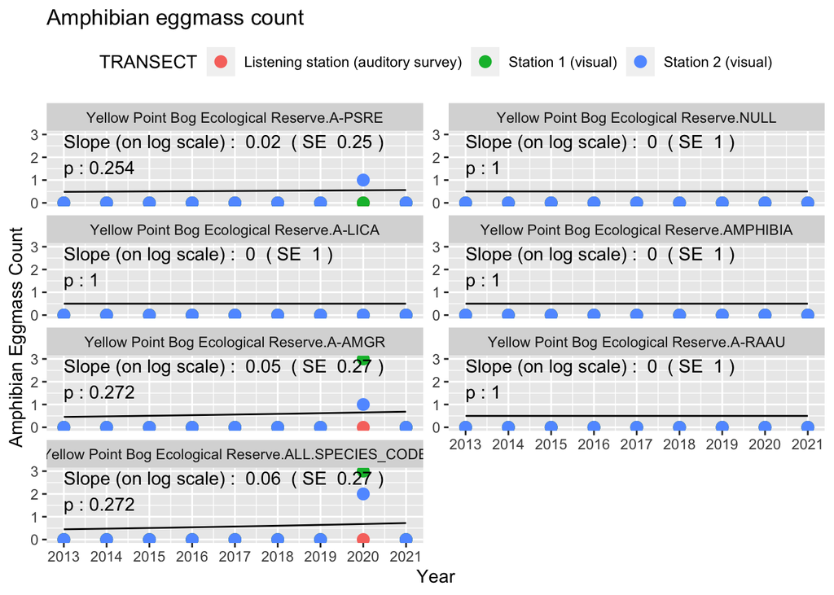

Figure 2: Summary plot of the trend in number of egg masses. Because the analysis was done on the logarithmic scale, the fitted trend line is not a straight line but curved.

The estimated slopes for each SPECIES_CODE and for all SPECIES_CODE pooled are:

Estimated slopes (on logarithmic scale)

[output not shown]

Because the analysis is done on the logarithmic scale, the interpretation of the slopes is straight forward. For example, if the estimated slope is .02, then the number of eggmasses is estimated to be increasing by 2%/year.

```
 *** Diagnostic plot for SPECIES_CODE  A-PSRE
```

```
 *** Diagnostic plot for SPECIES_CODE  NULL
```

```
 *** Diagnostic plot for SPECIES_CODE  A-LICA
```

```
 *** Diagnostic plot for SPECIES_CODE  AMPHIBIA
```

```
 *** Diagnostic plot for SPECIES_CODE  A-AMGR
```

```
 *** Diagnostic plot for SPECIES_CODE  A-RAAU
```

```
 *** Diagnostic plot for SPECIES_CODE  ALL.SPECIES_CODE
```

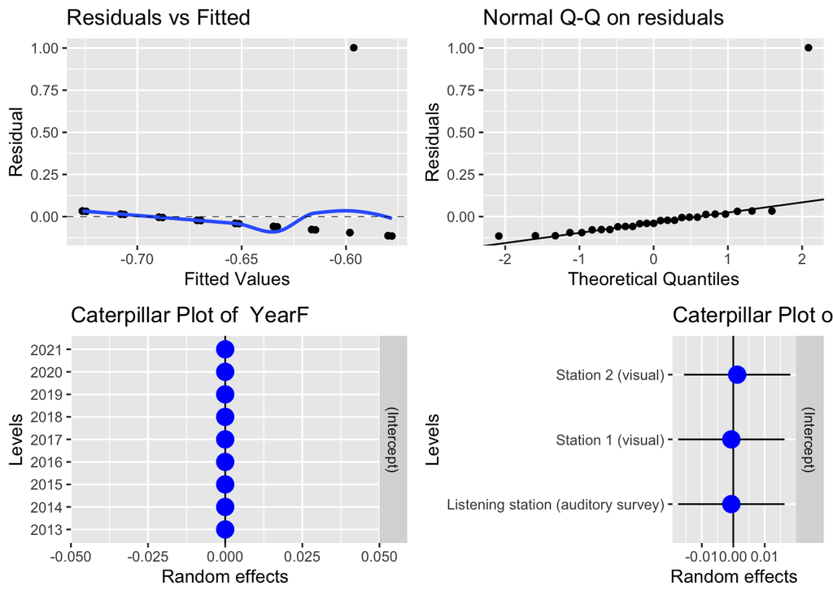

Figure 3: Model fit diagnostic plots from trend in egg masses

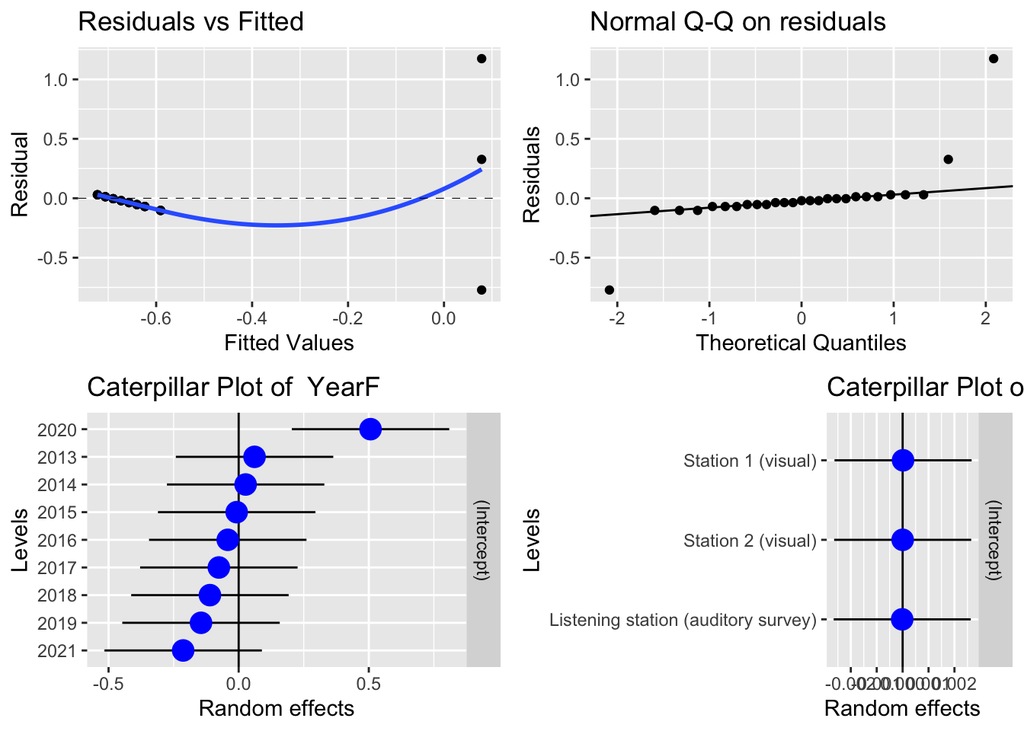

Figure 7: Model fit diagnostic plots from trend in egg masses

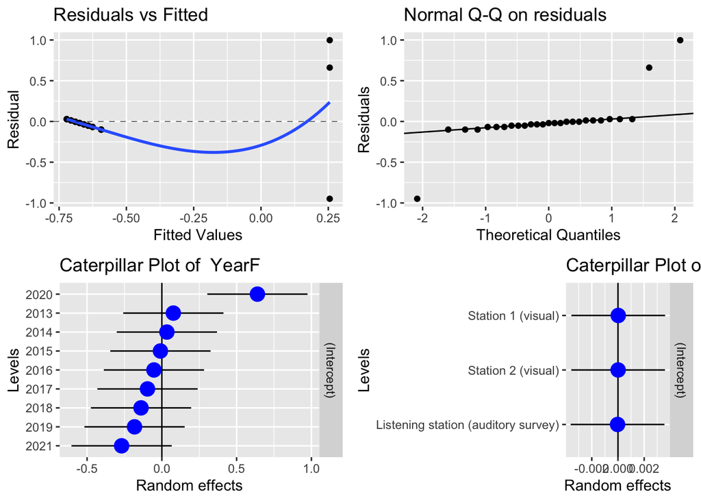

Figure 9: Model fit diagnostic plots from trend in egg masses

It will also be possible to covariates such as mean winter temperature or degree days in the year to try and explain some of the variation over time using a multiple regression. With only 9 years of data available, this not sensible.

Whenever an analysis of a trend over time is conducted, the analysis should test and adjust for autocorrelation. Autocorrelation usually isn’t a problem (and likely cannot be detected) unless you have 10+ years of data. The test for autocorrelation commonly used is the Durbin-Watson test and the following table is a summary of the results.

Estimated autocorrelation

| SPECIES_CODE | Autocorrelation | P-value |
| --- | --- | --- |
| A-PSRE | -0.31 | p = 0.214 |
| NULL | 0.67 | p < .001 |
| A-LICA | 0.67 | p < .001 |
| AMPHIBIA | 0.67 | p < .001 |
| A-AMGR | -0.33 | p = 0.226 |
| A-RAAU | 0.67 | p < .001 |
| ALL.SPECIES_CODE | -0.34 | p = 0.242 |

If there is evidence of autocorrelation (p-value is small) with a postive autocorrelation please contact me for assistance. Negative autocorrelation is not a concern, but indicate a “cyclical” trend in population numbers (i.e., high numbers in one year followed by low numbers in the next year, and vice versa) which may be of biological interest.

This analysis was conducted at the total count level (over all SPECIES_CODE) and also for individual SPECIES_CODE – but the data are likely to very sparse and not useful for individual SPECIES_CODE. One potential problem is that in some cases, SPECIES_CODE information is only recorded at the Genus or higher level. In these case, this data will have to discarded when the analysis is done at the SPECIES_CODE level, but then you are making an implicit assumption that recording at the Genus level happens at random and is unrelated to the response. If this assumption is violated (e.g. perhaps when there are larger number of amphibians, it is too difficult to record at the individual SPECIES_CODE level) then this is not occurring at random and some effort must be made to “split” the genus level information among the SPECIES_CODE.

In theory, the actual number of eggs in each egg mass could also be used rather simply the number of egg masses. I did not do this analysis because (a) it makes little sense to average the size of the egg mass over the different SPECIES_CODE and (b) the number of eggs in the egg mass may not represent the total number laid because of unknown amounts of predation.

## 4.2 Number of Adults.

# 5 Power analysis

A power/sample size analysis was conducted to determine the number of years of sampling needed to detect changes over time. The steps in the power/sample size analysis are:

- Compute a single number summarizing the response at this site in each year. The number of eggmasses is currently recorded at the transect level within each year so this needs to be averaged. Only the number of egg massess for all species will be used in the poper analysis.
- Analyze the log(mean response) using a simple linear regression. This will give an estimate of the combined year-specific and sampling variation around regression line (overall sd).
- Use the overall SD to estimate power and sample size requirements.

Here are the overall number of eggmasss for each year for each response:

```
  Year mean.count mean.response                Response
1 2013        0.0           0.0 Eggmasses - all species
2 2014        0.0           0.0 Eggmasses - all species
3 2015        0.0           0.0 Eggmasses - all species
4 2016        0.0           0.0 Eggmasses - all species
5 2017        0.0           0.0 Eggmasses - all species
6 2018        0.0           0.0 Eggmasses - all species
7 2019        0.0           0.0 Eggmasses - all species
8 2020        2.5           2.5 Eggmasses - all species
9 2021        0.0           0.0 Eggmasses - all species
```

The above data needs to be checked if there are any suspicious values.

We use the *lm()* function to fit linear regression over time on the log(scale) and obtain the combined year-specific effect (process error) plus sampling variation standard deviation (Table 1).

Table 1: Estimated residual (process + sampling) standard deviation

| Response | Process + sampling SD |
| --- | --- |
| Eggmasses - all species | 0.5821 |

This is then used to estimate the power to detect various proportional changes over time (Figure 10).

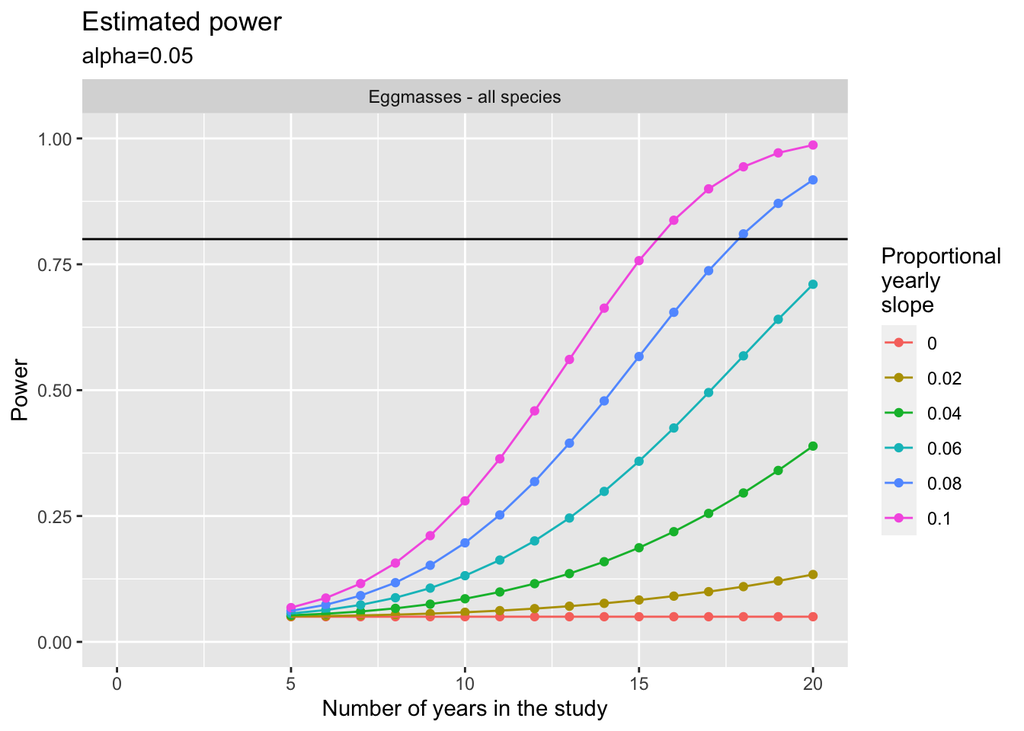

Figure 10: Estimated power to detect proportional changes over time

The proportional yearly slope indicates the effect size of interest. For example, a value of .02 would indicated a 2% change/year in the mean response.

In cases of high variability, the power is uniformly low to detect the yearly proportion change over time. In cases of low variability power is uniformly very high to detect the yearly proportion change over time.

# 6 Summary

Some caution is required to ensure that all transects are visited equally often in a year. In this balanced design, it is straightforward to compute statistics over all measurements of a transect and all transects in a year have the same number of visit. It is possible to modify the analysis is only some transects are visited on a particular date with an unequal number of visits to a transect in a year. A simple way to deal with unbalance would be to delete some of the observations, but better methods are available.

Trends over time could also occur in the diversity of the amphibians. In theory, standard diversity measures could be used and tracked over time, but these have a very strong assumption that all SPECIES_CODE are equally detectable by the observer. This is unlikely to be true. Secondly, the actual counts are quite small, and diversity measures that rely on actual counts (e.g. Simpson’s diversity) will not perform well. For this reason, I do not recommend an analysis on the diversity of the observations. I am extremely dubious that this protocol as implemented will produce any useful monitoring information at the study area level except for disaster detection (e.g. all SPECIES_CODE vanish). Even then, the absence of a detection does not imply that the SPECIES_CODE was not present – it could simply be a false negative. The current study does not provide any information to estimate detection probabilities.

As an example of how this protocol could be improved is based on large scale surveys of occupancy. The shoreline would be divided in many (at least 50) segments. On each visit, the presence/absence of amphibians would be recorded at the segment level. Then standard occupancy models could be used to estimate the proportion of segments that are occupied. Changes in the occupancy probability over time would be an indication that the population is increasing/decreasing over time.

Or this particular study area could be embedded into a much larger regional analysis where again, multiple visits are made in a year to estimate detection probabilities and changes in occupancy serve as an index to changes in the population.

# 7 References

Kuznetsova A, Brockhoff PB, Christensen RHB (2017). lmerTest Package: Tests in Linear Mixed Effects Models. Journal of Statistical Software, 82, 1-26. doi:10.18637/jss.v082.i13

MacKenzie, D. I., J. D. Nichols, J. A. Royle, K. H. Pollock, L.L. Bailey, and J. E. Hines. 2005. Occupancy Estimation and Modeling - Inferring Patterns and Dynamics of SPECIES_CODE Occurrence. Elsevier Publishing.

R Core Team (2022). R: A language and environment for statistical computing. R Foundation for Statistical Computing, Vienna, Austria. https://www.R-project.org/.